# Assignment 3

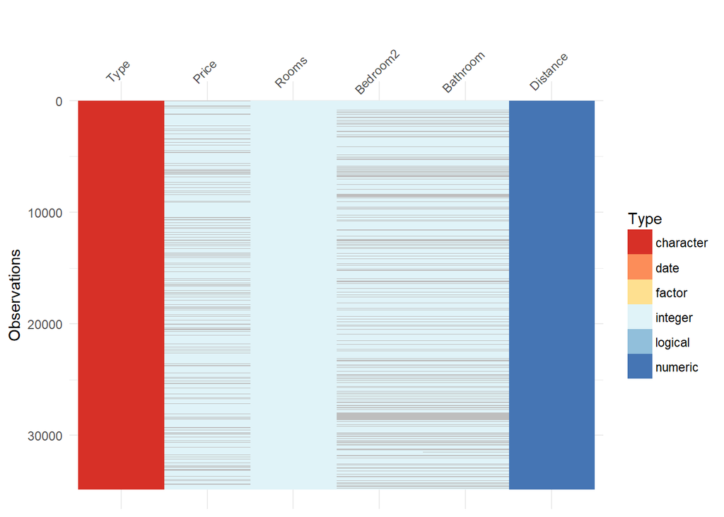

```r
library(tidyverse)
library(visdat)
library(naniar)
library(impute)
library(broom)
houses <- read_csv("data/Melbourne_housing_FULL.csv")
houses <- select(houses,Price,Rooms,Type,Distance,Bedroom2,Bathroom)
vis_dat(houses, palette = "cb_safe")
```

# 1. From this graph we can find out that the data for type is the character, the data for Price; Rooms; Bedrooms; bedrooms2 and Bathrooms are the integer and the data of Distance is numeric. And we had also found out that there is some shadow on the colour lump of Price Bedroom2 and Bathroom. That means we had the data missing on that variables. And the Bedroom2 have the same shadow with Bathroom.

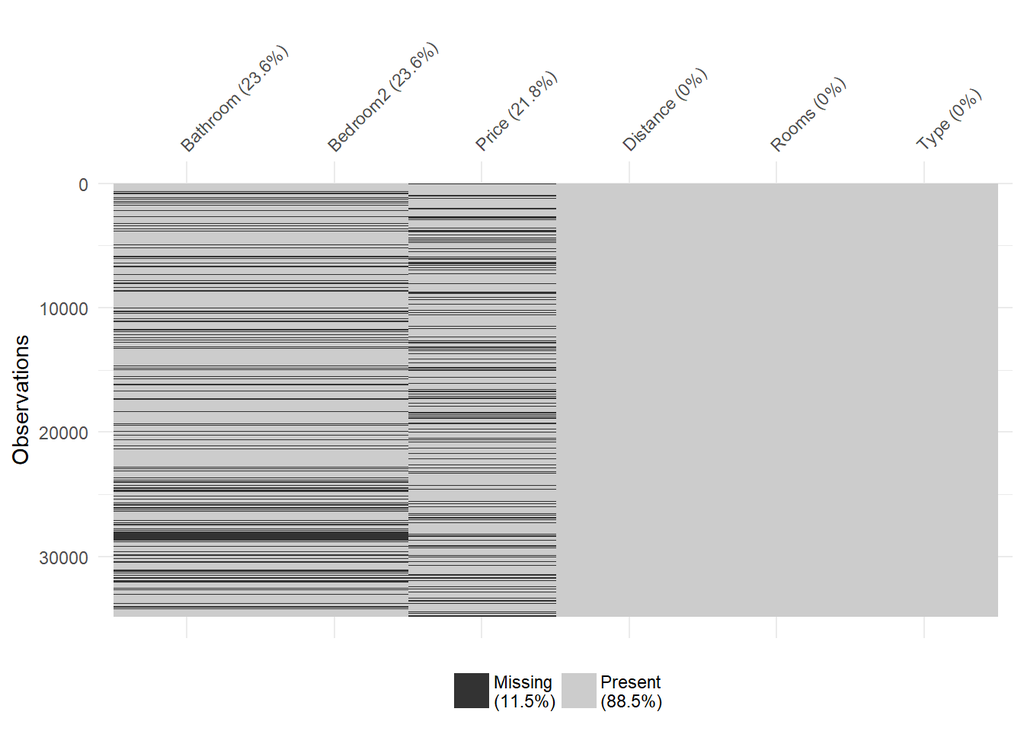

```r
vis_miss(houses, sort_miss=TRUE)
```

```r
s_miss <- miss_summary(houses)
s_miss$miss_df_prop
```

```
## [1] 0.1150128
```

```r
s_miss$miss_var_prop
```

```
## [1] 0.6666667
```

```r
s_miss$miss_case_table
```

```
## [[1]]
## # A tibble: 4 x 3
##   n_miss_in_case n_cases pct_miss
##            <int>   <int>    <dbl>
## 1              0   20800    59.7
## 2              1    5837    16.7
## 3              2    6443    18.5
## 4              3    1777     5.10
```